# La programmation orientée objet (POO)

Un paradigme de programmation très répandu (Python, Java, C++, etc.)

Aujourd'hui:

- des exemples introductifs pour votre intuition
- les notions de bases de la POO
  - attribut
  - méthode
  - constructeur
  - définir vos propres classes
- compléments pour aller plus loin: UML, méthodes magiques, espaces de noms,

À venir: l'articulation entre classes (agrégation, composition, héritage)

Cette présentation est à compléter par l'étude du site https://francoisbrucker.github.io/cours_informatique/cours/coder-et-d%C3%A9velopper/programmation-objet/#classes-objets.

# Promenade parmi les objets

## Variables vs. fonctions

Vous avez appris à manipuler deux types d'entités:

- des variables: pour stocker des **données**
- des fonctions: pour effectuer des **actions**

```python
def calcule_aire_carré(longueur_côté):
    return longueur_côté ** 2
a = 3.14
b = calcule_aire_carré(a)
print(a, b)
```

```
3.14 9.8596
```

Un objet regroupe données et actions dans une seule entité!

## Un compteur

```python
from compteur_mpci import Compteur

c = Compteur()
print(c)
print(type(c))
```

```
Compteur de valeur 0
<class 'compteur_mpci.Compteur'>
```

```python
c.incrémente()
print(c)
```

```
Compteur de valeur 1
```

```python
print(c.valeur)
c.valeur = 20
print(c)
```

```
1
Compteur de valeur 20
```

- `c` est un objet de type `Compteur`
- `c.incrémente()` *agit* sur le compteur, comme une fonction
- `c.valeur` stocke la *donnée* utile au compteur
- un objet est une entité pouvant stocker des *données* et effectuer des *actions*.

## Une classe pour les chaînes

Quel est le type exact d'une chaîne de caractères?

```python
s = "Bonjour!"
print(s)
print(type(s))
```

```
Bonjour!
<class 'str'>
```

C'est une classe!

```python
# Convertir une chaîne en majuscules...
s_upper = s.upper()  # Une "fonction" de conversion?
print(s_upper)
```

```
BONJOUR!
```

## Une classe pour les entiers

Quel est le type exact d'un entier?

```python
a = 42
print(type(a))
a.to_bytes()  # encore une sorte de "fonction" attachée à la variable?
```

```
<class 'int'>
```

```
b'*'
```

Encore une classe! Et une sorte de fonction!

## Une classe pour les complexes

Saviez-vous qu'il y a une classe pour les complexes?

```python
print(1j ** 2)
z = 2 - 1j *0.5
print(z)
print(type(z))
```

```
(-1+0j)
(2-0.5j)
<class 'complex'>
```

Un complexe se caractérise par sa partie réelle et sa partie imaginaire. Comment y accéder?

```python
x = z.real
y = z.imag
print(x, y)
print(type(x), type(y))
```

```
2.0 -0.5
<class 'float'> <class 'float'>
```

Comment calculer le conjugué?

```python
zc = z.conjugate()
print(zc, type(zc))
```

```
(2+0.5j) <class 'complex'>
```

## Une classe pour les dates et les heures

Ça existe et c'est très pratique!

```python
import datetime
mpci_day0 = datetime.datetime(day=3, month=9, year=2024, hour=9, minute=0, second=0)
print(type(mpci_day0))
print(mpci_day0)
```

```
<class 'datetime.datetime'>
2024-09-03 09:00:00
```

```python
print(mpci_day0.day)
print(mpci_day0.month)
print(mpci_day0.year)
print(mpci_day0.hour, mpci_day0.minute, mpci_day0.second)
```

```
3
9
2024
9 0 0
```

```python
now = datetime.datetime.today()
print(type(now))
print(now)
```

```
<class 'datetime.datetime'>
2025-03-19 10:49:34.921872
```

```python
d = now.__sub__(mpci_day0) # Soustraire deux objets datetime
print(type(d))
print("Je suis en MPCI depuis", d.days, "jours et", d.seconds, "secondes.")
```

```
<class 'datetime.timedelta'>
Je suis en MPCI depuis 197 jours et 6574 secondes.
```

```python
d = now - mpci_day0 # Plus pratique avec l'opérateur -
print("Je suis en MPCI depuis", d.days, "jours et", d.seconds, "secondes.")
```

```
Je suis en MPCI depuis 197 jours et 6574 secondes.
```

## Et les graphiques?

Encore des classes!

```
<class 'matplotlib.figure.Figure'>
<class 'numpy.ndarray'> (2,)
<class 'matplotlib.axes._axes.Axes'>
```

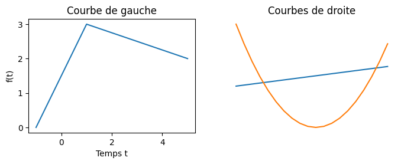

```python
import matplotlib.pyplot as plt

fig, axes = plt.subplots(1,2, figsize=(8, 2.5))
axes[0].plot([-1, 1, 5], [0, 3, 2])
axes[0].set_xlabel('Temps t')
axes[0].set_ylabel('f(t)')
axes[0].set_title('Courbe de gauche')
axes[1].plot([x for x in range(-10, 10)])
axes[1].plot([x ** 2 - 50 for x in range(-10, 10)])
axes[1].set_axis_off()
axes[1].set_title('Courbes de droite')
print(type(fig))
print(type(axes), axes.shape)
print(type(axes[0]))
```

## À retenir

- En Python, tout est objet!
- Un objet permet de regrouper des données et des actions dans une seule entité pour de nombreuses bonnes raisons:
  - DRY
  - compartimentation et modularité du code
  - structuration du code
  - lisibilité

## Et maintenant

- Classe, objet: késako?
- Comment utiliser une classe existante?
- Comment créer une nouvelle classe?
- Tout savoir sur les composants des classes?

# Notions de base

## Classe, objet, instance

De façon très similaire à un *type*, une *classe* est un modèle pour entités ayant des caractéristiques communes.

*Instancier* une classe signifie créer une entité de cette classe.

Un *objet* est une *instance* d'une *classe*.

```python
# Exemple
c = Compteur()
print(type(c))
```

```
<class 'compteur_mpci.Compteur'>
```

L'objet `c` est une instance de la classe `Compteur`.

## Attribut (de l'objet!)

- concept proche de celui de variable
- stocke les données propres à l'objet dans l'espace de nom de la classe ou de l'objet
- accessible en lecture et écriture avec la syntaxe `nom_objet.nom_attribut`, sans parenthèses

```python
c.valeur = 3
c.valeur += 1
print(c)
```

```
Compteur de valeur 4
```

## Méthode

- concept proche de celui de fonction
- effectue des actions propres à la classe ou à l'objet
- accessible avec la syntaxe `nom_objet.nom_méthode(arguments)`, avec des parenthèses

```python
c.incrémente()
print(c)
c.initialise()
print(c)
```

```
Compteur de valeur 5
Compteur de valeur 0
```

## Créer une classe

### Déclarer le nom de la classe

On utilise le mot clé `class` et on crée un bloc

```python
class Compteur:
    pass
```

Complétons le code de cette classe!

### Le constructeur: pour instancier la classe

On crée une méthode `__init__(self, argument1, argument2, ...)`. Elle est appelée automatiquement quand on crée un objet à l'aide du nom de la classe.

```python
class Compteur:
    def __init__(self):
        print("Création d'un compteur")

c = Compteur()  # Création de l'objet
print(type(c))
print(c)
```

```
Création d'un compteur
<class '__main__.Compteur'>
<__main__.Compteur object at 0x1040d4d10>
```

Et la variable `self`?

### Attributs et méthodes

Il est assez naturel de créer et manipuler des attributs et des méthodes lors de la définition d'une classe.

La variable `self`, premier argument de chaque méthode, désigne l'instance courante.

```python
class Compteur:
    def __init__(self):
        self.valeur = 0

    def incrémente(self):
        self.valeur += 1

c1 = Compteur()
c2 = Compteur()
print(c1.valeur, c2.valeur)
c1.incrémente()
print(c1.valeur, c2.valeur)
c2.valeur = 3
print(c1.valeur, c2.valeur)
```

```
0 0
1 0
1 3
```

Vous remarquez:

- les méthodes créées avec le mot clé `def` (comme les fonctions), à l'intérieur de la classe
- l'attribut `valeur` créé dans le constructeur, modifié dans la méthode `incrémente` et à l'extérieur (`c2.valeur`)
- la méthode `incrémente`
- l'attribut `valeur` a des valeurs différents dans les deux instances `c1` et `c2`
- `self` permet d'accéder à l'attribut `valeur` propre à l'instance considérée
- `self` apparaît dans la déclaration de la méthode (`def incrémente(self)`) mais pas dans l'appel à la méthode (`c1.incrémente()`)

`self` apparaît dans la déclaration de la méthode (`def incrémente(self)`) mais pas dans l'appel à la méthode (`c1.incrémente()`)

**Explication:** c'est un raccourci bien utile pour la syntaxe avec argument `Classe.methode(instance)`.

```python
class Compteur:
    def __init__(self):
        self.valeur = 0

    def incrémente(self):
        self.valeur += 1

c = Compteur()
c.incrémente()  # Appel sans argument self
print(c.valeur)
Compteur.incrémente(c) # Appel équivalent avec argument self
print(c.valeur)
```

```
1
2
```

# Compléments d'objet

## Très pratiques: les méthodes magiques/spéciales

- exemples: `__init__`, `__str__`, `__sub__`, `__add__`
- permettent de définir des comportements spéciaux: instanciation, conversion en chaîne de caractères, opérateurs mathématiques, etc.
- facile à reconnaitre par leurs noms qui commencent et finissent par deux `_`
- on les découvrira petit à petit

```python
class Compteur:
    def __init__(self):
        self.valeur = 0

    def __str__(self):
        return f'Compteur de valeur {self.valeur}'

c = Compteur()
print(c)
print(" -> " + str(c))
```

```
Compteur de valeur 0
 -> Compteur de valeur 0
```

```python
import datetime
mpci_day0 = datetime.date(day=3, month=9, year=2024)
now = datetime.date.today()
d = now.__sub__(mpci_day0) # Soustraire deux objets datetime
print("Je suis en MPCI depuis", d.days, "jours.")
d = now - mpci_day0  # C'est bien plus pratique comme ça
print("Je suis en MPCI depuis", d.days, "jours.")
```

```
Je suis en MPCI depuis 197 jours.
Je suis en MPCI depuis 197 jours.
```

Vous utilisez déjà des méthodes spéciales sans le savoir!

```python
x = 1 + 2
# au lieu de
y = (1).__add__(2)

print(x == y)
# au lieu de
print(x.__eq__(y))
```

```
True
True
```

## L'UML : vive les maquettes

- UML = Unified Modeling Language
- langage très vaste : on se contente de quelques éléments
- très utile et répandu pour décrire des classes

```
classDiagram
      class NomDeLaClasse{
          attributs
          constructeur()
          méthodes()
      }
```

```
classDiagram
      class Compteur{
          valeur : int
          Compteur()
          incrémente()
          initialise()
          __str__() str
      }
```

## Améliorer l'exemple de la classe `Compteur`

- Ajouter un pas pour incrémenter le compteur d'une valeur différente de 1
- Autoriser une valeur initiale différente de 0
- Comparer des compteurs avec `==`, `<`, etc.

```
classDiagram
      class Compteur{
          valeur : int
          pas : int
          Compteur(pas=1, valeur=0)
          incrémente()
          initialise()
          __str__() str
          __eq__(other) bool
          __lt__(other) bool
      }
```

```python
class Compteur:
    def __init__(self, pas=1, valeur=0):
        self.valeur = valeur
        self.pas = pas

    def incrémente(self):
        self.valeur = self.valeur + self.pas

    def __str__(self):
        return f'Compteur de valeur {self.valeur} et de pas {self.pas}'

    def __eq__(self, other):
        return self.valeur == other.valeur

    def __lt__(self, other):
        return self.valeur < other.valeur

c1 = Compteur(3)
c2 = Compteur(valeur=10)
c1.incrémente()
c2.incrémente()
c1.incrémente()

print(c1)
print(c2)

print(c1 < c2, c1 == c2)
```

```
Compteur de valeur 6 et de pas 3
Compteur de valeur 11 et de pas 1
True False
```

**Autres exemples**

```
classDiagram
    class Personne{
        nom : str
        prénom : str
        date_naissance : datetime.date
        Personne(prénom, nom, date_naissance)
        calcule_age() int
    }
    class Compte{
        titulaire : Personne
        solde : float
        Compte(titulaire)
        retire(montant) float
        dépose(montant) float
    }
```

```
classDiagram
    class Point{
        x : float
        y : float
        Point(x, y)
        distance(other) float
    }
    class Polygone{
        sommets : [Point]
        Polygone(liste_sommets)
        périmètre() float
        aire() float
    }
```

## Espaces de nom

Plusieurs espaces de noms sont imbriqués dans un objet:

- l'espace de nom d'une méthode
- l'espace de nom de l'instance
- l'espace de nom de la classe

```python
class Compteur:
    pas = 1  # un attribut de classe dans l'espace de nom de la classe
    def __init__(self, valeur=0):
        # argument valeur dans l'espace de nom de la méthode __init__
        self.valeur = valeur  # attribut self.valeur dans l'espace de nom de l'instance

    def incrémente(self):
        self.valeur = self.valeur + self.pas

    def __str__(self):
        return f'Compteur de valeur {self.valeur} et de pas {self.pas}'

c = Compteur(2)
c.incrémente()
print(c.valeur, c.pas, Compteur.pas)
try:
    print(Compteur.valeur)  # Erreur!!
except AttributeError as e:
    print(e)
```

```
3 1 1
type object 'Compteur' has no attribute 'valeur'
```

```python
c1 = Compteur(valeur=3)
c2 = Compteur(valeur=-5)
print(c1)
print(c2)
Compteur.pas = 2  # modification de l'attribut de classe
print(c1)
print(c2)
```

```
Compteur de valeur 3 et de pas 1
Compteur de valeur -5 et de pas 1
Compteur de valeur 3 et de pas 2
Compteur de valeur -5 et de pas 2
```

# Conclusion

- Vous avez les bases théoriques sur les classes:
  - classes, objets, instances
  - attributs, méthodes
  - constructeur
  - `self`
  - UML, méthodes magiques, espaces de noms
- Il faut maintenant pratiquer, pratiquer, pratiquer, de la découverte à l'automatisme
- Prochaines séances:
  - TP pour pratiquer
  - *Être et Avoir*, ou l'articulation entre classes (agrégation, composition, héritage)